# ML practice 6: recap

## Немного организационного

Один из компонентов итоговой оценки за семестр – прохождение онлайн-курса по ML. Для зачета по этой части необходимо выполнить не меньше 60% курса.

**Базовый** рекомендованный курс [Statistical Learning от Stanford](https://lagunita.stanford.edu/courses/HumanitiesSciences/StatLearning/Winter2016/about). Еще есть книга [An Introduction to Statistical Learning with Applications in R](http://www-bcf.usc.edu/~gareth/ISL/)

Возможные курсы:

- [Machine Learning by Andrew Ng на Coursera](https://www.coursera.org/learn/machine-learning) (глубже про математические основы)
- [Practical Machine Learning на Coursera](https://www.coursera.org/learn/practical-machine-learning) (про пакет caret)
- [Introduction to Machine Learning на DataCamp](https://www.datacamp.com/courses/introduction-to-machine-learning-with-r)
- Supervised Learning in R на DataCamp [Regression](https://www.datacamp.com/courses/supervised-learning-in-r-regression) + [Classification](https://www.datacamp.com/courses/supervised-learning-in-r-classification)

Плюс можно выбрать курс самостоятельно, но при этом его нужно согласовать с преподавателем.

## Резюме занятий

Сегодня занятие на повторение и обобщение изученного. Итак, что мы рассмотрели за первый модуль:

- Обучение с учителем. Регрессия vs классификация
- Разделение на тестовую и обучающую выборки: зачем и кому это нужно (`createDataPartition()`)
- Bias-variance tradeoff
- Кросс-валидация (`caret::train(..., trControl = trainControl(method="cv", number=10))`)
- Несбалансированные выборки (`caret::train(..., trControl = trainControl(..., sampling = "down"))`)
- Ошибки предсказания и качество предсказания
  - Регрессия: RSS, RMSE
  - Классификация: accuracy, precision, recall, sensitifity, specificity (`caret::confusionMatrix()`)
  - Классификация с возможностью сдвига границы между классами: ROC, AUC (`pROC::roc()`, `pROC::auc()`)
- Алгоритмы
  - Регрессия:
    - регрессионное дерево (`ctree()`)
    - линейная регрессия (`lm()`)
    - регрессия с регуляризацией (`glmnet()`)
  - Классификация:
    - классификационное дерево (`ctree()`)
    - метод опорных векторов (`svm()`)
    - метод k ближайших соседей (`knn3()`, `knn()`)
    - логистическая регрессия (`glm(..., family = binomial(link = "logit"))`)
    - логистическая регрессия с регуляризацией (`glmnet(..., family = "binomial")`)

Все эти методы можно вызывать и с помощью пакета `caret`. Например:

- `caret::train(..., method = 'knn')`
- `caret::train(..., method = 'svmPoly')`
- `caret::train(..., method = 'glmnet')`
- [поддерживаемые модели](https://topepo.github.io/caret/available-models.html)

Примерный алгоритм действий

## Практика

А теперь тренируемся!

```r
library(caret)
```

```r
library(ggplot2)
library(dplyr)
```

### Данные

Датасет, с которым мы работаем сегодня – о прокате велосипедов. Хотим предсказывать, сколько человек воспользуются прокатом. Файл, с которым мы будем работать, с Kaggle https://www.kaggle.com/c/bike-sharing-demand/data, но первоначальный (немного почищенный – см. для сравнения hour.csv и DatasetDescription.txt) - с UCI Machine Learning Repository https://archive.ics.uci.edu/ml/datasets/Bike+Sharing+Dataset

> Кстати, если хочется посмотреть на качество итоговой модели по сравнению с остальными, то можно поучаствовать в соревновании на Kaggle https://www.kaggle.com/c/bike-sharing-demand. Только обратите внимание, что там в качестве предсказания используется Root Mean Squared Logarithmic Error [(RMSLE)](https://www.kaggle.com/c/bike-sharing-demand#evaluation)

Данные о прокате за 2011 и 2012 гг. от Capital Bikeshare system, Washington D.C., USA

- datetime - hourly date + timestamp
- season - 1 = spring, 2 = summer, 3 = fall, 4 = winter
- holiday - whether the day is considered a holiday
- workingday - whether the day is neither a weekend nor holiday
- weather

  1: Clear, Few clouds, Partly cloudy, Partly cloudy 2: Mist + Cloudy, Mist + Broken clouds, Mist + Few clouds, Mist 3: Light Snow, Light Rain + Thunderstorm + Scattered clouds, Light Rain + Scattered clouds 4: Heavy Rain + Ice Pallets + Thunderstorm + Mist, Snow + Fog
- temp - temperature in Celsius
- atemp - “feels like” temperature in Celsius
- humidity - relative humidity
- windspeed - wind speed
- casual - number of non-registered user rentals initiated
- registered - number of registered user rentals initiated
- count - number of total rentals

```r
bike = read.csv("~/shared/minor3_2017/3-SecondYear-ML/practice-6-recap/train.csv")
str(bike)
```

```
## 'data.frame':    10886 obs. of  12 variables:
##  $ datetime  : Factor w/ 10886 levels "2011-01-01 00:00:00",..: 1 2 3 4 5 6 7 8 9 10 ...
##  $ season    : int  1 1 1 1 1 1 1 1 1 1 ...
##  $ holiday   : int  0 0 0 0 0 0 0 0 0 0 ...
##  $ workingday: int  0 0 0 0 0 0 0 0 0 0 ...
##  $ weather   : int  1 1 1 1 1 2 1 1 1 1 ...
##  $ temp      : num  9.84 9.02 9.02 9.84 9.84 ...
##  $ atemp     : num  14.4 13.6 13.6 14.4 14.4 ...
##  $ humidity  : int  81 80 80 75 75 75 80 86 75 76 ...
##  $ windspeed : num  0 0 0 0 0 ...
##  $ casual    : int  3 8 5 3 0 0 2 1 1 8 ...
##  $ registered: int  13 32 27 10 1 1 0 2 7 6 ...
##  $ count     : int  16 40 32 13 1 1 2 3 8 14 ...
```

Преобразуем переменные к факторам или наоборот, где нужно

```r
bike$datetime = as.character(bike$datetime)
bike$season = as.factor(bike$season)
bike$holiday = as.factor(bike$holiday)
```

Преобразуем дату к формату даты и извлечем из нее отдельно год, месяц, день недели

```r
library(lubridate)
head(bike$datetime)
```

```
## [1] "2011-01-01 00:00:00" "2011-01-01 01:00:00" "2011-01-01 02:00:00"
## [4] "2011-01-01 03:00:00" "2011-01-01 04:00:00" "2011-01-01 05:00:00"
```

```r
tail(bike$datetime) #значит, дата в формате год-месяц-день время
```

```
## [1] "2012-12-19 18:00:00" "2012-12-19 19:00:00" "2012-12-19 20:00:00"
## [4] "2012-12-19 21:00:00" "2012-12-19 22:00:00" "2012-12-19 23:00:00"
```

```r
bike$datetime = ymd_hms(bike$datetime)
bike = bike %>% mutate(year = factor(year(datetime)), month = month(datetime), weekday = wday(datetime))
```

Посмотрим на температуру и влажность

```r
summary(bike$temp)
```

```
##    Min. 1st Qu.  Median    Mean 3rd Qu.    Max.
##    0.82   13.94   20.50   20.23   26.24   41.00
```

```r
summary(bike$humidity)
```

```
##    Min. 1st Qu.  Median    Mean 3rd Qu.    Max.
##    0.00   47.00   62.00   61.89   77.00  100.00
```

- Нужно ли их нормализовывать?

```r
bike$temp = bike$temp/(max(bike$temp) - min(bike$temp))
```

- Какую задачу решаем? Регрессия или классификация?

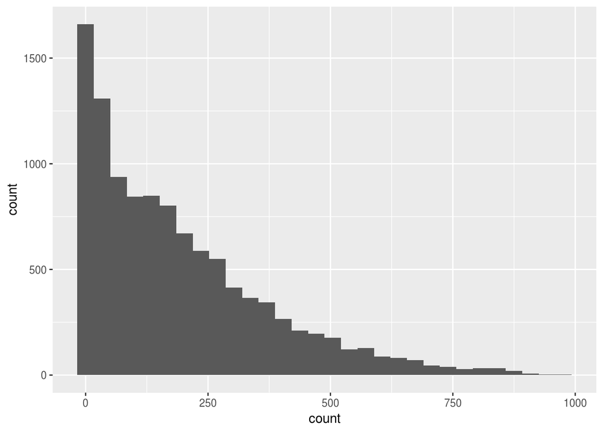

```r
ggplot(data = bike) + geom_histogram(aes(x = count))
```

- Какую метрику будем использовать для оценки качества?
- Разбиение на тестовую и обучающую

```r
set.seed(100) #You shoud put here your own number
test.ind = createDataPartition(bike$count, p = 0.2, list = FALSE)
bike.test = bike[test.ind,]
bike.main = bike[-test.ind,]
```

- Построим модель на основе температуры, времени года и праздник / не праздник. Будем сразу строить модель с учетом кросс-валидации

```r
set.seed(3)
lm.model <- train(count~temp+season+holiday, data = bike.main, method = "lm",
                  trControl = trainControl(method = "cv", number = 10))
print(lm.model)
```

```
## Linear Regression
##
## 8707 samples
##    3 predictors
##
## No pre-processing
## Resampling: Cross-Validated (10 fold)
## Summary of sample sizes: 7836, 7835, 7836, 7836, 7837, 7836, ...
## Resampling results:
##
##   RMSE      Rsquared   MAE
##   163.6227  0.1890769  123.8011
##
## Tuning parameter 'intercept' was held constant at a value of TRUE
```

Посмотрим на модель

```r
summary(lm.model)
```

```
##
## Call:
## lm(formula = .outcome ~ ., data = dat)
##
## Residuals:
##     Min      1Q  Median      3Q     Max
## -321.95 -111.64  -30.38   75.45  774.34
##
## Coefficients:
##             Estimate Std. Error t value Pr(>|t|)
## (Intercept)  -52.267      5.799  -9.013  < 2e-16 ***
## temp         538.090     14.820  36.308  < 2e-16 ***
## season2      -37.913      6.257  -6.059 1.43e-09 ***
## season3      -94.492      7.799 -12.117  < 2e-16 ***
## season4       27.142      5.192   5.228 1.75e-07 ***
## holiday1      -4.513     10.450  -0.432    0.666
## ---
## Signif. codes:  0 '***' 0.001 '**' 0.01 '*' 0.05 '.' 0.1 ' ' 1
##
## Residual standard error: 163.6 on 8701 degrees of freedom
## Multiple R-squared:  0.1889, Adjusted R-squared:  0.1885
## F-statistic: 405.4 on 5 and 8701 DF,  p-value: < 2.2e-16
```

Посмотрим на стабильность предсказания

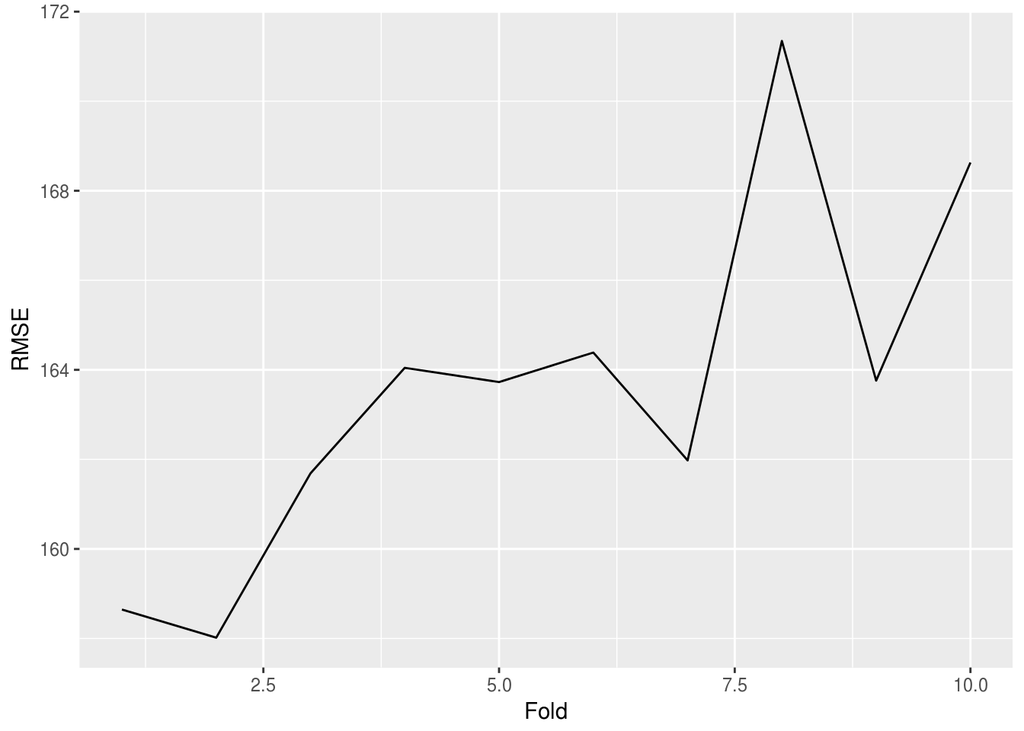

```r
ggplot() + geom_line(aes(y = lm.model$resample$RMSE, x = 1:10)) + xlab("Fold") + ylab("RMSE")
```

Посмотрим предсказание на тестовой выборке

```r
lm.predict = predict(lm.model, bike.test)
RMSE.lm = sqrt(mean((lm.predict - bike.test$count)^2))
RMSE.lm
```

```
## [1] 159.7096
```

Давайте теперь посмотрим на модель с регуляризацией

```r
library(glmnet)
X.train <- model.matrix(count~temp+season+holiday-1, data=bike.main)
X.test <- model.matrix(count~temp+season+holiday-1, data=bike.test)

cv.glmnet.fit <- cv.glmnet(X.train, bike.main$count)
cv.glmnet.fit
```

[output not shown]

[output cut: 145 more lines]

```r
best.lambda <- cv.glmnet.fit$lambda.min
best.lambda
```

```
## [1] 0.1289116
```

```r
lasso.model = glmnet(X.train, bike.main$count, lambda = best.lambda)
coef(lasso.model)
```

```
## 7 x 1 sparse Matrix of class "dgCMatrix"
##                     s0
## (Intercept) -74.453810
## temp        533.863958
## season1      23.260503
## season2     -13.112660
## season3     -69.085409
## season4      50.831768
## holiday1     -3.752652
```

```r
lasso.predictions <- predict(lasso.model, X.test)
lasso.RMSE <- sqrt(mean((lasso.predictions-bike.test$count)^2))
lasso.RMSE
```

```
## [1] 159.7488
```

Построим то же самое, но с помощью пакета `caret` (отличия в значениях из-за случайности в кросс-валидации, в методах разницы нет)

```r
net.model <- train(count~temp+season+holiday, data = bike.main, method = "glmnet",
                  trControl = trainControl(method = "cv", number = 10))
print(net.model)
```

```
## glmnet
##
## 8707 samples
##    3 predictors
##
## No pre-processing
## Resampling: Cross-Validated (10 fold)
## Summary of sample sizes: 7836, 7836, 7836, 7836, 7836, 7836, ...
## Resampling results across tuning parameters:
##
##   alpha  lambda      RMSE      Rsquared   MAE
##   0.10    0.1441441  163.5390  0.1896832  123.8049
##   0.10    1.4414406  163.5525  0.1895815  123.8494
##   0.10   14.4144065  164.2828  0.1847686  124.7967
##   0.55    0.1441441  163.5379  0.1896933  123.8023
##   0.55    1.4414406  163.5836  0.1893353  123.8976
##   0.55   14.4144065  165.4417  0.1756551  126.1012
##   1.00    0.1441441  163.5380  0.1896924  123.8035
##   1.00    1.4414406  163.6373  0.1888895  123.9732
##   1.00   14.4144065  166.7178  0.1652919  127.5919
##
## RMSE was used to select the optimal model using  the smallest value.
## The final values used for the model were alpha = 0.55 and lambda
##  = 0.1441441.
```

```r
coef(net.model$finalModel)
```

```
## 6 x 73 sparse Matrix of class "dgCMatrix"
```

```
##    [[ suppressing 73 column names 's0', 's1', 's2' ... ]]
```

[output not shown]

[output cut: 43 more lines]

[output not shown]

```r
net.predict = predict(net.model, bike.test)
RMSE.net = sqrt(mean((net.predict - bike.test$count)^2))
RMSE.net
```

```
## [1] 159.7477
```

И наконец, можем посмотреть на дерево

```r
tree.model <- train(count~temp+season+holiday, data = bike.main, method = "ctree",
                  trControl = trainControl(method = "cv", number = 10))
print(tree.model)
```

```
## Conditional Inference Tree
##
## 8707 samples
##    3 predictors
##
## No pre-processing
## Resampling: Cross-Validated (10 fold)
## Summary of sample sizes: 7837, 7836, 7836, 7835, 7836, 7837, ...
## Resampling results across tuning parameters:
##
##   mincriterion  RMSE      Rsquared   MAE
##   0.01          161.5309  0.2098788  121.4898
##   0.50          161.8138  0.2067383  121.6953
##   0.99          162.8107  0.1971080  122.5273
##
## RMSE was used to select the optimal model using  the smallest value.
## The final value used for the model was mincriterion = 0.01.
```

[figure not shown]

```r
plot(tree.model$finalModel)
```

```r
tree.predict = predict(tree.model, bike.test)
RMSE.tree = sqrt(mean((tree.predict - bike.test$count)^2))
RMSE.tree
```

```
## [1] 157.0523
```

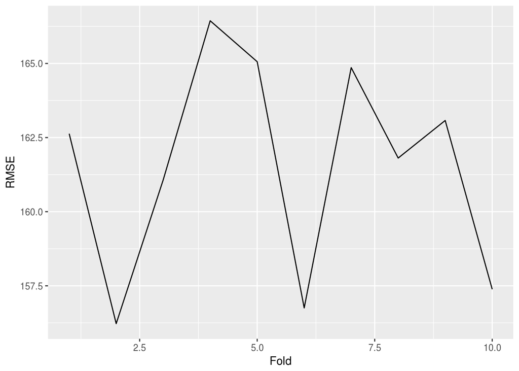

```r
ggplot() + geom_line(aes(y = tree.model$resample$RMSE, x = 1:10)) + xlab("Fold") + ylab("RMSE")
```

Какая модель лучше?

```r
RMSE.lm
```

```
## [1] 159.7096
```

```r
RMSE.net
```

```
## [1] 159.7477
```

```r
RMSE.tree
```

```
## [1] 157.0523
```

Можно построить распределение предсказаний по часам

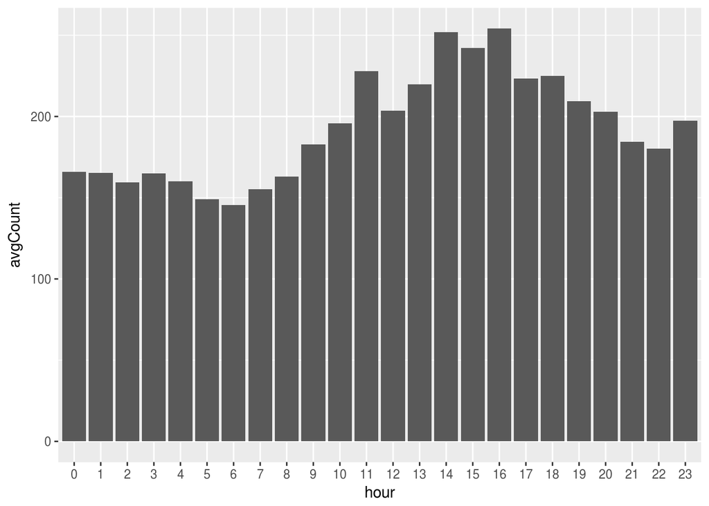

```r
bike.test = bike.test %>% mutate(hour = factor(hour(datetime)))
data = data.frame(hour  = bike.test$hour, predictCount = tree.predict)
data %>% group_by(hour) %>% summarise(avgCount = mean(predictCount)) %>%
  ggplot() + geom_bar(aes(x = hour, y = avgCount), stat = "identity")
```

- Это усредненные показатели. А что можно сделать, чтобы получить такое предсказание для конкретного дня?

**Ваша очередь:**

1. Попробуйте логарифмировать `count`. Изменилось ли что-то в структуре моделей? При изменении первоначального датасета не забудьте обновить тестовую и обучающую выборки

```r
bike$logcount = log(bike$count+1)
bike.test = bike[test.ind,]
bike.main = bike[-test.ind,]
```

И кстати, в таком случае удобно считать Root Mean Squared Logarithmic Error

```r
#RMSLE = sqrt(mean((predict - bike.test$logcount)^2)) нужно заменить predict на вектор предсказанных значений
```

2. У проката, очевидно, должны быть какие-то циклы в течение дня. Включите в модель hour как предиктор. Что изменилось?
3. Посмотрите на остальные предикторы. Что еще можно добавить? Как преобразовать? Постройте другие модели, сравните. Не забудьте убрать из данных ненужные переменные, если используете `count~.`
4. Представьте, что у вас обратная задача – у вас есть данные о прокате, а нужно узнать, был ли день праздником или нет (переменная `holiday`). Дату в качестве предиктора использовать нельзя.
- Какой тип задачи в этом случае?
- Сбалансированные ли данные?

```r
 summary(bike$holiday)
```

```
##     0     1
## 10575   311
```